# Transport w USA po 11 września 2001 r.

Prognozy na podstawie wcześniejszych danych i analiza odchyleń

Autor

Benvenuteo

Opublikowano

20 października 2026

# 1 Najważniejsze wyniki

Analiza porównuje miesięczne obserwacje po wrześniu 2001 r. z prognozami wyznaczonymi wyłącznie na podstawie danych sprzed tego miesiąca. Model wybrano oddzielnie dla każdego środka transportu, wykorzystując wcześniejszą walidację czasową. **Wyniki są odchyleniami od scenariusza modelowego, a nie samodzielnym dowodem efektu przyczynowego zamachów.**

Tabela 1: Pierwsze 12 miesięcy po zdarzeniu: IX 2001–VIII 2002.

| Szereg | Model | Odchylenie skumulowane (%) | Miesiące poniżej dolnej granicy 95% |
| --- | --- | --- | --- |
| Air | ARIMA | -16,08 | 12 |
| Car | ARIMA | -0,37 | 1 |
| Rail | SNaive | -0,08 | 0 |

W pierwszym roku lotnicze pasażerom mile były o **16,08% niższe** od sumy wartości prognozowanych przez model ARIMA. Analogiczne odchylenie dla kolei wyniosło **-0,08%**, a dla przebiegu pojazdów drogowych **-0,37%**. Wielkości te mają wspólną interpretację procentową, ale dotyczą różnych miar transportu.

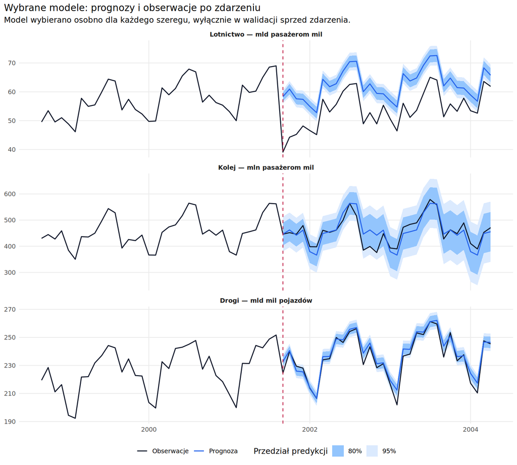

Rysunek 1: Obserwacje i prognozy wybranych modeli. Zacienienie oznacza miesięczne przedziały predykcji.

# 2 Problem badawczy i dane

## 2.1 Cel, pytania i kryteria jakości

Celem jest ocena skali i utrzymywania się zmian w transporcie względem wcześniejszych wzorców trendu i sezonowości. Badanie odpowiada na pytania: jak duże były różnice dla lotnictwa, czy utrzymywały się w kolejnych miesiącach i jak wyglądały na tle kolei oraz ruchu drogowego.

Główny horyzont interpretacji to pierwsze 12 miesięcy po zdarzeniu. Okna 3 i 6 miesięcy pokazują początkową dynamikę, a 32 miesiące pełną dostępną ścieżkę. Sukces metodologiczny oznacza poprawne jednostki, brak informacji z przyszłości przy wyborze modelu, porównywalne miary błędu, jawną niepewność i możliwość odtworzenia analizy. Z góry nie zakładamy zwycięstwa bardziej złożonego modelu.

## 2.2 Źródło i znaczenie zmiennych

Załączony zbiór odpowiada zakresowi od stycznia 1990 do kwietnia 2004 r. tabeli C1 raportu *Estimated Impacts of September 11th on US Travel* Bureau of Transportation Statistics (BTS). W repozytorium zachowano oryginał Markdown i jego bezstratną konwersję do CSV.

| Szereg | Znaczenie | Jednostka źródłowa | Jednostka na wykresach |
| --- | --- | --- | --- |
| Air | Lotnicze revenue passenger miles | tys. pasażerom mil | mld pasażerom mil |
| Rail | Kolejowe passenger miles | pasażerom mile | mln pasażerom mil |
| Car | Vehicle miles traveled (VMT) | mld mil pojazdów | mld mil pojazdów |

Pasażerom mile są miarą pracy przewozowej, a nie liczbą pasażerów. Nazwa `Car` jest skrótem roboczym: seria VMT dotyczy przebiegu pojazdów drogowych i nie mierzy liczby pasażerów ani wyłącznie samochodów osobowych. Według opisu BTS dane nie rozdzielają podróży lokalnych i dalekobieżnych. Nie można więc ograniczać wniosków do samych podróży dalekobieżnych ani sumować tych trzech serii.

Źródła: [tabela C1 BTS](https://www.bts.gov/archive/publications/estimated_impacts_of_9_11_on_us_travel/table_c01) i [opis zakresu w rozdziale 2](https://www.bts.gov/archive/publications/estimated_impacts_of_9_11_on_us_travel/chapter_02). Analiza pozostaje przy dostarczonych kompletnych miesiącach; nie uzupełniano późniejszego niekompletnego wiersza widocznego na stronie źródłowej.

## 2.3 Kontrola jakości i preprocessing

Zbiór zawiera **172 miesiące, 3 szeregi i 516 obserwacji w formacie długim**. Kontrola nie wykazała brakujących miesięcy, duplikatów, braków danych, wartości nieskończonych ani niedodatnich. Nie stosowano imputacji. Obserwacji z września 2001 r. nie usunięto jako wartości odstającej: stanowi ona przedmiot badania.

W R dane wczytano jako `tibble`, przekształcono przez `pivot_longer()` i zapisano jako miesięczny `tsibble` z kluczem `Travel` i indeksem `Month`. Wartości źródłowe są zachowane; przeliczenia jednostek służą wyłącznie prezentacji.

Tabela 2: Statystyki opisowe całej próby, po przeliczeniu do jednostek prezentacyjnych.

| Szereg | N | Minimum | Mediana | Średnia | Maksimum | Odchylenie standardowe |
| --- | --- | --- | --- | --- | --- | --- |
| Air | 172 | 29,67 | 49,46 | 49,26 | 69,00 | 8,60 |
| Car | 172 | 153,25 | 209,70 | 210,25 | 261,30 | 24,95 |
| Rail | 172 | 326,87 | 477,07 | 482,76 | 664,01 | 68,55 |

# 3 Eksploracja i sezonowość

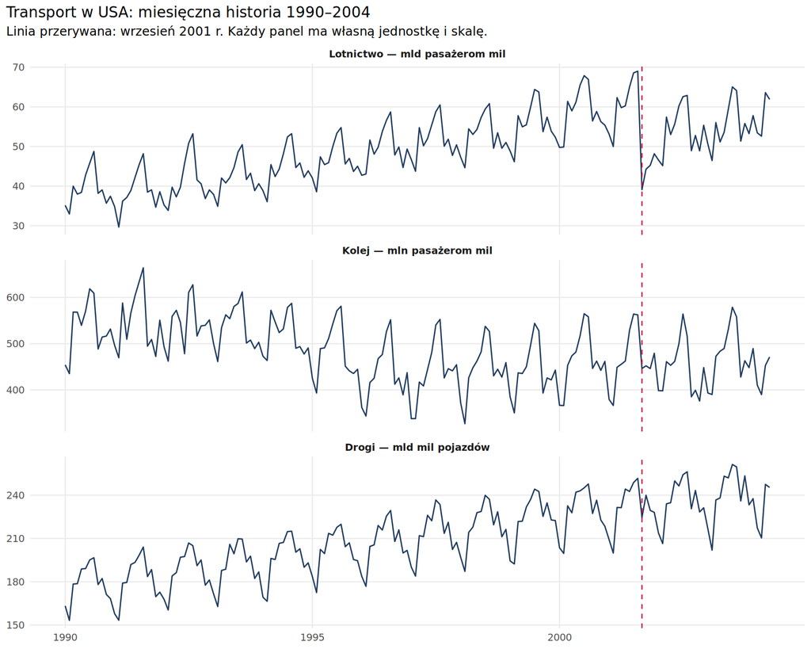

Rysunek 2: Pełna historia w odrębnych jednostkach i skalach.

Lotnictwo i ruch drogowy wykazują długookresowy wzrost przed zdarzeniem, a kolej ma bardziej zmienny poziom i wyraźniejsze zmiany kierunku. We wszystkich seriach występuje cykl roczny. Dlatego porównanie sierpnia i września bez uwzględnienia sezonowości byłoby mylące.

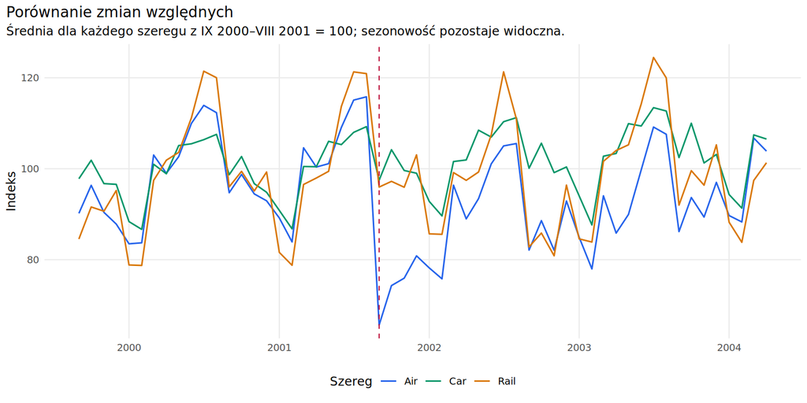

Rysunek 3: Porównanie względne z normalizacją do średniej sprzed zdarzenia.

## 3.1 Wykresy sezonowe i podszeregów

Poniższe wykresy wykorzystują wyłącznie próbę sprzed września 2001 r. Wykresy sezonowe porównują miesiące kolejnych lat, a podszeregi pokazują ewolucję wartości dla tego samego miesiąca.

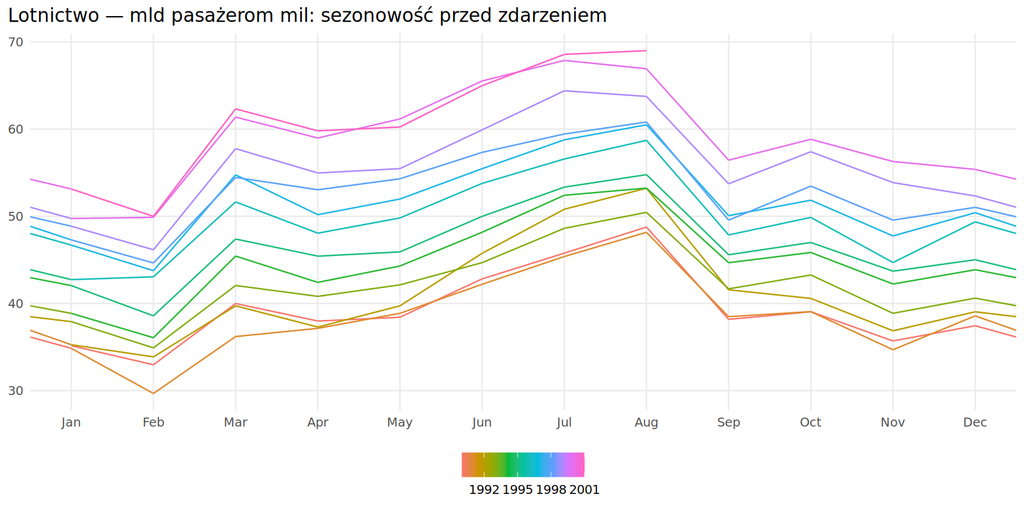

Rysunek 4: Roczne wzorce sezonowe lotnictwa, kolei i ruchu drogowego.

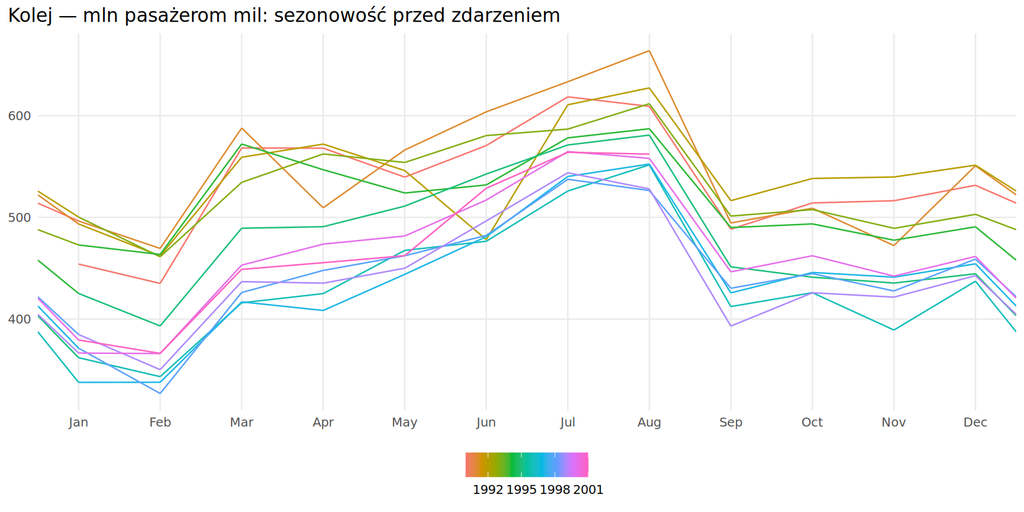

Rysunek 5: Roczne wzorce sezonowe lotnictwa, kolei i ruchu drogowego.

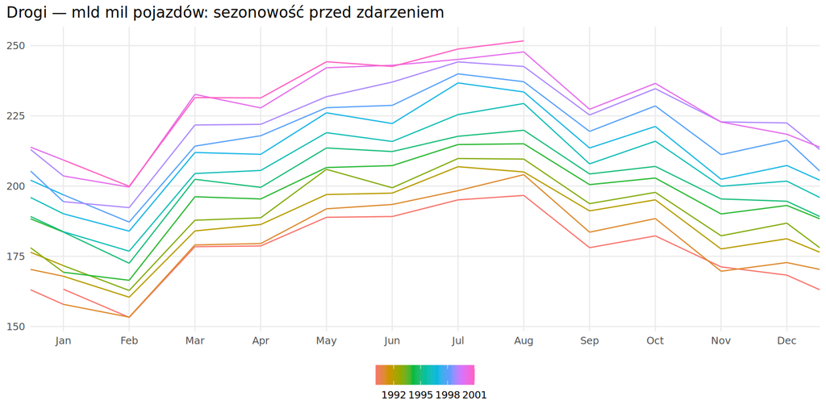

Rysunek 6: Roczne wzorce sezonowe lotnictwa, kolei i ruchu drogowego.

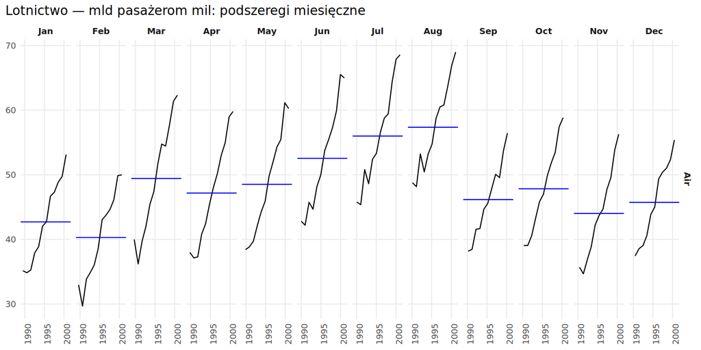

Rysunek 7: Podszeregi miesięczne dla trzech miar transportu.

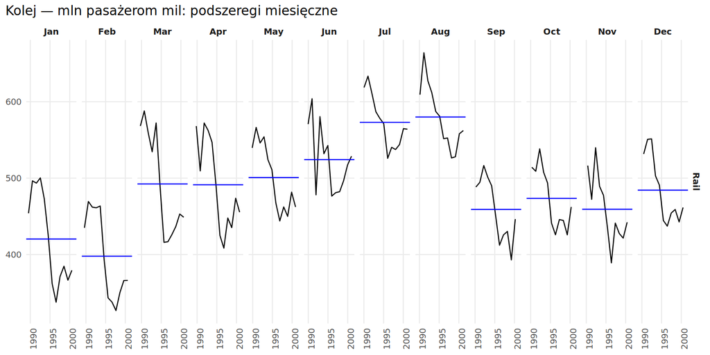

Rysunek 8: Podszeregi miesięczne dla trzech miar transportu.

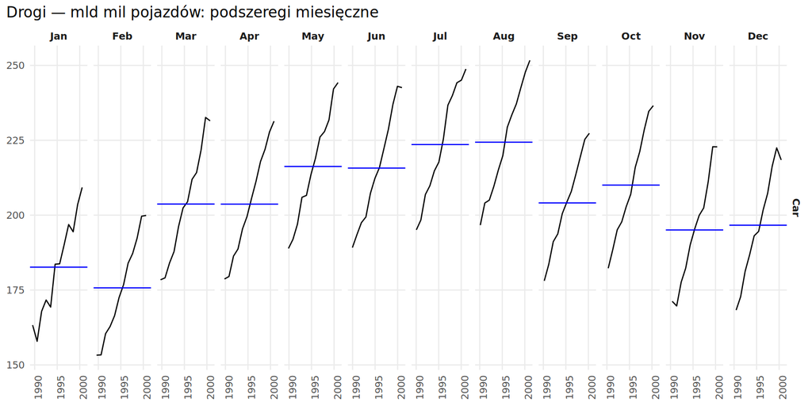

Rysunek 9: Podszeregi miesięczne dla trzech miar transportu.

## 3.2 Korelacje i autokorelacja

ACF opisuje zależność pojedynczego szeregu od jego własnych opóźnień. Korelacje między środkami transportu wyznaczono osobno. Porównano poziomy i roczne zmiany logarytmiczne, aby ocenić, jak silnie wynik zależy od wspólnego trendu i wzorca sezonowego.

Tabela 3: Opisowe korelacje Pearsona przed i po zdarzeniu.

| Okres | Miara | Para | N | Korelacja |
| --- | --- | --- | --- | --- |
| Przed | Poziomy | Air–Rail | 140 | -0,008 |
| Przed | Poziomy | Air–Car | 140 | 0,959 |
| Przed | Poziomy | Rail–Car | 140 | 0,052 |
| Przed | Zmiany log r/r | Air–Rail | 128 | -0,218 |
| Przed | Zmiany log r/r | Air–Car | 128 | 0,375 |
| Przed | Zmiany log r/r | Rail–Car | 128 | -0,034 |
| Po | Poziomy | Air–Rail | 32 | 0,689 |
| Po | Poziomy | Air–Car | 32 | 0,723 |
| Po | Poziomy | Rail–Car | 32 | 0,800 |
| Po | Zmiany log r/r | Air–Rail | 32 | -0,185 |
| Po | Zmiany log r/r | Air–Car | 32 | 0,209 |
| Po | Zmiany log r/r | Rail–Car | 32 | 0,258 |

Wysoka korelacja poziomów może wynikać ze wspólnego trendu lub sezonowości. Korelacje zmian rok do roku są także opisowe: transformacja nie gwarantuje niezależności obserwacji. Krótka próba po zdarzeniu oraz różne definicje miar dodatkowo ograniczają porównanie. Wyniki nie dowodzą przepływu tych samych pasażerów między środkami transportu.

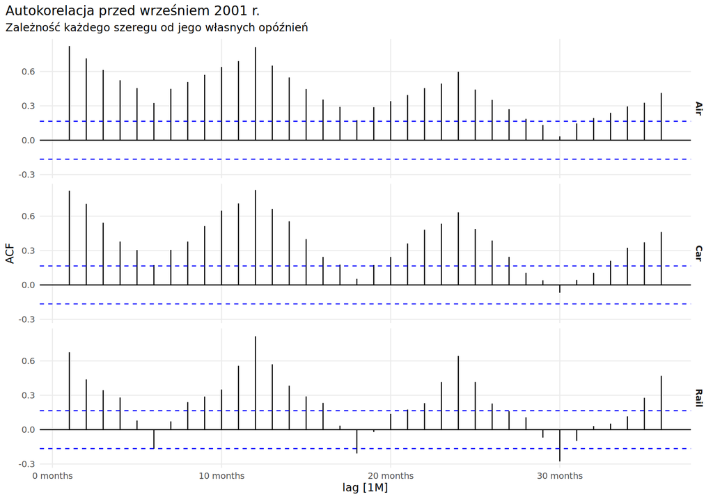

Rysunek 10: Autokorelacja miesięcznych serii w próbie uczącej.

# 4 Dekompozycja STL

Dla każdego szeregu zastosowano STL w próbie uczącej, ze stałym wzorcem sezonowym (`season(window = "periodic")`). Dekompozycja w oryginalnej skali ma postać addytywną: obserwacja = trend + sezonowość + reszta.

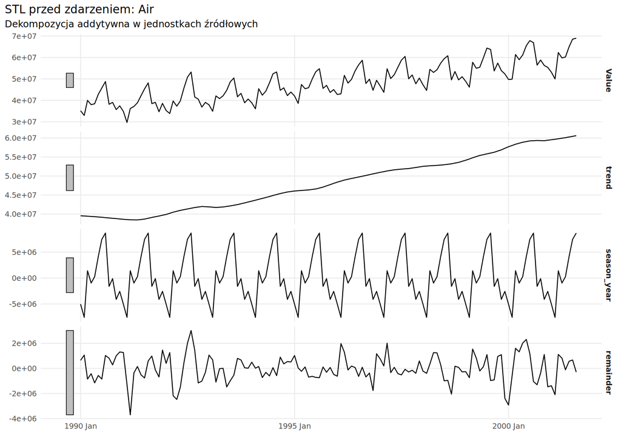

Rysunek 11: STL na danych sprzed zdarzenia; każda seria pozostaje w jednostkach źródłowych.

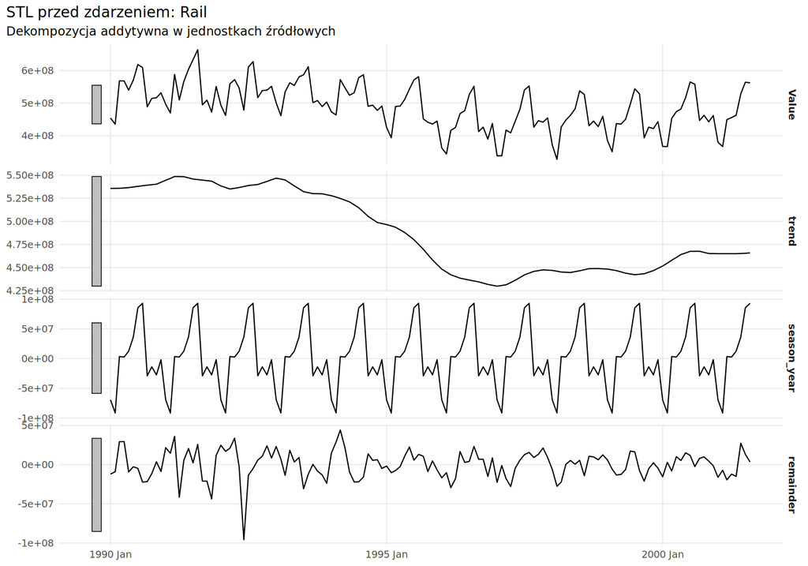

Rysunek 12: STL na danych sprzed zdarzenia; każda seria pozostaje w jednostkach źródłowych.

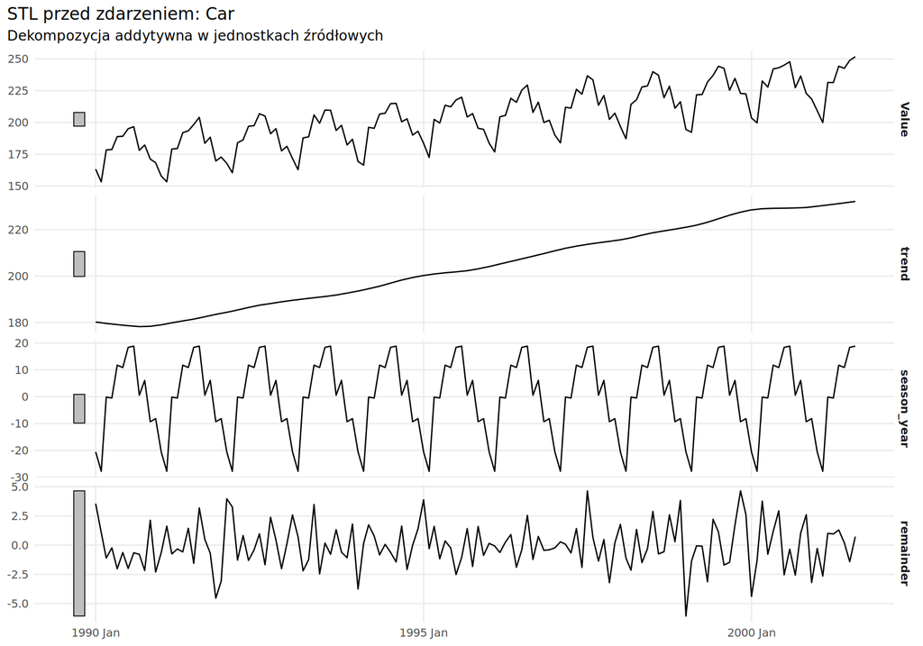

Rysunek 13: STL na danych sprzed zdarzenia; każda seria pozostaje w jednostkach źródłowych.

Ocena addytywności i multiplikatywności jest wizualna. **W analizie opisowej przyjmujemy przybliżenie addytywne dla wszystkich trzech szeregów.** Dla Air wzrost amplitudy bezwzględnej jest umiarkowany w porównaniu ze wzrostem poziomu; dla Car amplituda w milach pozostaje dość stabilna. W Rail wahania sezonowe nie zmniejszają się proporcjonalnie do spadku poziomu. Nie widać więc jednoznacznego, stałego mnożnika sezonowego. Jest to robocza ocena wykresów, a nie formalny test ani założenie idealnie stałej amplitudy w każdym roku.

STL w zwykłej skali służy tutaj opisowi. ETS może dobierać również elementy multiplikatywne. Modele ARIMA i wszystkie punkty odniesienia są estymowane w oryginalnej skali; nie porównywano dodatkowej siatki transformacji logarytmicznych. Taki jawny, ograniczony zakres ułatwia interpretację wyników.

# 5 Prognozowanie i wybór modelu

## 5.1 Podział chronologiczny

| Część danych | Okres | Miesiące | Zastosowanie |
| --- | --- | --- | --- |
| Przed zdarzeniem | I 1990–VIII 2001 | 140 | Estymacja i wcześniejsza walidacja |
| Po zdarzeniu | IX 2001–IV 2004 | 32 | Porównanie obserwacji z zamrożonym scenariuszem |

Wrzesień jest miesiącem zdarzenia. Agregacja miesięczna nie pozwala oddzielić pierwszych dziesięciu dni od pozostałej części miesiąca.

## 5.2 Sześć metod

| Metoda | Założenie |
| --- | --- |
| Mean | Stała prognoza równa średniej z historii |
| Naive | Stała prognoza równa ostatniej obserwacji |
| SNaive | Powtórzenie ostatniej dostępnej wartości z tego samego miesiąca roku |
| Drift | Ekstrapolacja przeciętnej historycznej zmiany |
| ETS | Automatyczny wybór modelu wygładzania wykładniczego |
| ARIMA | Automatyczny dobór sezonowej i niesezonowej struktury ARIMA |

Specyfikacje ETS i ARIMA dobierano na danych uczących w każdej iteracji. ARIMA wykorzystuje wyszukiwanie krokowe z AICc i bez przybliżania estymacji. Dobór rzędu różnicowania pozostawiono standardowym procedurom pakietu. Wyniki wszystkich metod są oceniane w tej samej skali oryginalnej.

## 5.3 Walidacja z rosnącym oknem

Pierwsze okno uczące obejmuje 60 miesięcy. Punkt prognozy przesuwano co 3 miesiące. Otrzymano **23 okna** z kompletem 12 kolejnych miesięcy do oceny. Żadna oceniana obserwacja nie pochodzi z okresu po zdarzeniu. Dla kontroli długiego horyzontu dostępnych jest **17 pełnych okien 32-miesięcznych**.

Główne kryterium wyboru to MASE uśrednione po wszystkich prognozach dla horyzontów 1–12. Mianownik w każdym oknie jest średnim bezwzględnym błędem sezonowo naiwnym, obliczonym tylko na jego danych uczących z opóźnieniem 12. Przy remisie rozstrzyga RMSE, a następnie nazwa modelu. Nakładające się okna dają zależne błędy; przedstawiony ranking ma charakter porównawczy, bez testowania istotności różnic między modelami.

RMSE silniej karze duże błędy; MAE opisuje przeciętne odchylenie bezwzględne; MAPE wyraża błąd procentowo, ale jest asymetryczne. MASE umożliwia porównania między skalami. MASE poniżej 1 odnosi się do sezonowego błędu referencyjnego na treningu, a nie automatycznie do zwycięstwa nad rzeczywistą prognozą SNaive w walidacji.

Tabela 4: Walidacja przed zdarzeniem; główne horyzonty 1–12 miesięcy.

| Szereg | Model | MASE | RMSE | MAE | MAPE (%) |
| --- | --- | --- | --- | --- | --- |
| Air | ARIMA | 0,615 | 1,661 | 1,302 | 2,431 |
| Air | ETS | 0,860 | 2,272 | 1,821 | 3,388 |
| Air | SNaive | 1,124 | 2,734 | 2,374 | 4,426 |
| Air | Naive | 2,310 | 6,009 | 4,902 | 9,127 |
| Air | Drift | 2,364 | 6,137 | 5,023 | 9,484 |
| Air | Mean | 4,364 | 10,678 | 9,272 | 16,558 |
| Car | ARIMA | 0,468 | 3,186 | 2,410 | 1,097 |
| Car | ETS | 0,529 | 3,461 | 2,723 | 1,256 |
| Car | SNaive | 1,066 | 6,053 | 5,432 | 2,508 |
| Car | Drift | 2,571 | 16,490 | 13,164 | 6,232 |
| Car | Naive | 2,603 | 16,205 | 13,310 | 6,225 |
| Car | Mean | 4,729 | 27,694 | 24,275 | 10,796 |
| Rail | SNaive | 0,812 | 30,697 | 24,180 | 5,559 |
| Rail | ETS | 0,814 | 31,046 | 24,408 | 5,633 |
| Rail | ARIMA | 0,863 | 32,365 | 25,782 | 5,789 |
| Rail | Naive | 1,820 | 68,125 | 54,203 | 12,447 |
| Rail | Drift | 1,862 | 69,730 | 55,469 | 12,730 |
| Rail | Mean | 2,425 | 85,775 | 73,070 | 17,796 |

W tabelach miar RMSE i MAE wyrażono odpowiednio w mld pasażerom mil dla Air, mln pasażerom mil dla Rail i mld mil pojazdów dla Car. MASE nie ma jednostki, a MAPE jest procentem.

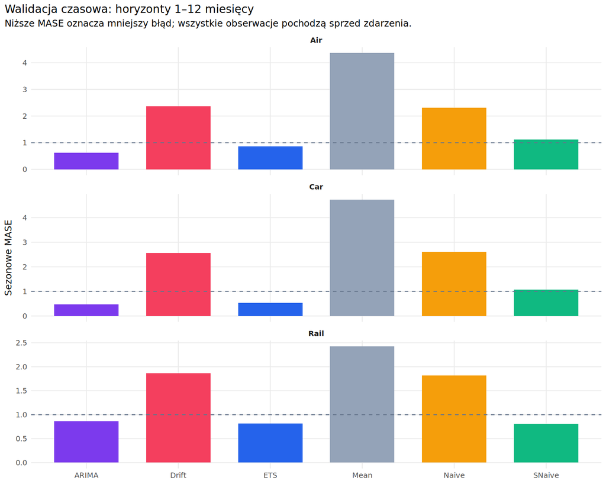

Rysunek 14: Porównanie MASE w walidacji sprzed zdarzenia.

Tabela 5: Modele wybrane przed porównaniem z okresem po zdarzeniu.

| Szereg | Model | MASE | Pokrycie 80% w walidacji (%) | Pokrycie 95% w walidacji (%) |
| --- | --- | --- | --- | --- |
| Air | ARIMA | 0,615 | 73,551 | 93,841 |
| Car | ARIMA | 0,468 | 71,014 | 88,043 |
| Rail | SNaive | 0,812 | 89,130 | 99,638 |

Pokrycie oznacza odsetek rzeczywistych obserwacji mieszczących się w danym przedziale predykcji w walidacji. Odchylenie od nominalnych 80% lub 95% wskazuje ograniczenia kalibracji; samo wyznaczenie przedziału nie gwarantuje jego poprawności.

Dla Car nominalny przedział 95% pokrywa **88,04%** obserwacji walidacyjnych. To sygnał możliwego niedoszacowania niepewności, dlatego pojedynczych wyjść późniejszych obserwacji poza ten przedział nie traktujemy jako rozstrzygających testów wpływu zdarzenia.

## 5.4 Dopasowanie do treningu i ocena po zdarzeniu

Miary treningowe liczono na wspólnych miesiącach 13–140, aby każda metoda była oceniana na tej samej próbie. Są to błędy dopasowania z parametrami estymowanymi na całym treningu, więc nie zastępują oceny prognostycznej.

Tabela 6: Błędy dopasowania w próbie uczącej.

| Szereg | Model | MASE | RMSE | MAE | MAPE (%) |
| --- | --- | --- | --- | --- | --- |
| Air | ARIMA | 0,415 | 1,153 | 0,912 | 1,957 |
| Air | Drift | 1,688 | 4,762 | 3,705 | 7,778 |
| Air | ETS | 0,411 | 1,231 | 0,902 | 1,903 |
| Air | Mean | 3,183 | 8,541 | 6,989 | 14,592 |
| Air | Naive | 1,702 | 4,768 | 3,738 | 7,817 |
| Air | SNaive | 1,000 | 2,581 | 2,196 | 4,498 |
| Car | ARIMA | 0,345 | 2,411 | 1,768 | 0,878 |
| Car | Drift | 1,890 | 12,628 | 9,685 | 4,772 |
| Car | ETS | 0,337 | 2,258 | 1,729 | 0,846 |
| Car | Mean | 3,526 | 22,176 | 18,066 | 8,841 |
| Car | Naive | 1,895 | 12,645 | 9,708 | 4,772 |
| Car | SNaive | 1,000 | 5,789 | 5,124 | 2,496 |
| Rail | ARIMA | 0,638 | 21,742 | 16,476 | 3,453 |
| Rail | Drift | 1,611 | 56,057 | 41,631 | 8,921 |
| Rail | ETS | 0,598 | 21,124 | 15,453 | 3,193 |
| Rail | Mean | 2,222 | 70,025 | 57,418 | 12,424 |
| Rail | Naive | 1,616 | 56,055 | 41,754 | 8,935 |
| Rail | SNaive | 1,000 | 33,891 | 25,836 | 5,464 |

Tabela 7: Błędy prognoz po zdarzeniu: wszystkie 32 miesiące, bez ponownego wyboru modelu.

| Szereg | Model | MASE | RMSE | MAE | MAPE (%) |
| --- | --- | --- | --- | --- | --- |
| Air | ARIMA | 3,963 | 9,338 | 8,701 | 16,932 |
| Air | Drift | 8,743 | 19,992 | 19,196 | 37,409 |
| Air | ETS | 3,607 | 8,746 | 7,919 | 15,616 |
| Air | Mean | 3,196 | 8,560 | 7,018 | 12,380 |
| Air | Naive | 6,913 | 16,497 | 15,178 | 30,134 |
| Air | SNaive | 2,522 | 6,604 | 5,537 | 10,997 |
| Car | ARIMA | 0,582 | 4,058 | 2,982 | 1,309 |
| Car | Drift | 5,112 | 30,400 | 26,192 | 11,562 |
| Car | ETS | 0,505 | 3,738 | 2,588 | 1,135 |
| Car | Mean | 6,202 | 35,207 | 31,781 | 13,092 |
| Car | Naive | 3,406 | 22,038 | 17,453 | 7,806 |
| Car | SNaive | 1,532 | 8,961 | 7,851 | 3,306 |
| Rail | ARIMA | 0,683 | 23,523 | 17,653 | 4,063 |
| Rail | Drift | 4,559 | 129,033 | 117,794 | 27,386 |
| Rail | ETS | 0,661 | 23,799 | 17,070 | 3,918 |
| Rail | Mean | 1,979 | 61,466 | 51,138 | 11,817 |
| Rail | Naive | 4,107 | 117,544 | 106,099 | 24,757 |
| Rail | SNaive | 0,777 | 26,948 | 20,068 | 4,656 |

Tabela 8: Najlepsze metody z czterech wymaganych w zadaniu; trening i okres późniejszy według RMSE.

| Szereg | Trening: najniższy RMSE | Po zdarzeniu: najniższy RMSE | Wybór do scenariusza |
| --- | --- | --- | --- |
| Air | SNaive | SNaive | ARIMA |
| Car | SNaive | SNaive | ARIMA |
| Rail | SNaive | SNaive | SNaive |

**Model prognostyczny** wybieramy według jakości wcześniejszych prognoz poza próbą. **Do celu badania** wykorzystujemy ten sam zamrożony model jako przybliżenie kontynuacji wcześniejszych wzorców, z zastrzeżeniem jego niepewności. Dobre dopasowanie do faktycznego spadku po zdarzeniu nie świadczy samo w sobie o dobrym scenariuszu bez tego spadku. Tabela błędów po zdarzeniu realizuje porównanie wymagane w zadaniu, ale nie służy do zmiany wybranego modelu.

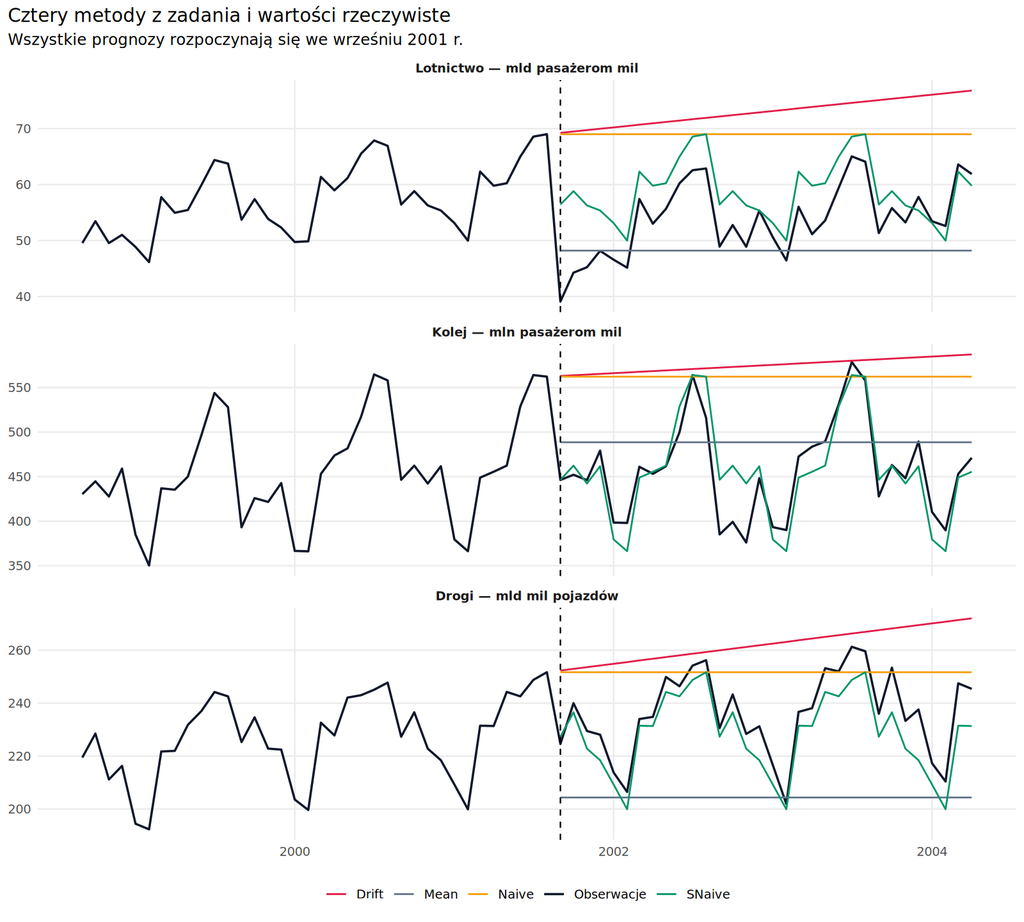

Rysunek 15: Wspólne porównanie Mean, Naive, SNaive i Drift z obserwacjami.

## 5.5 Horyzont i wrażliwość rankingu

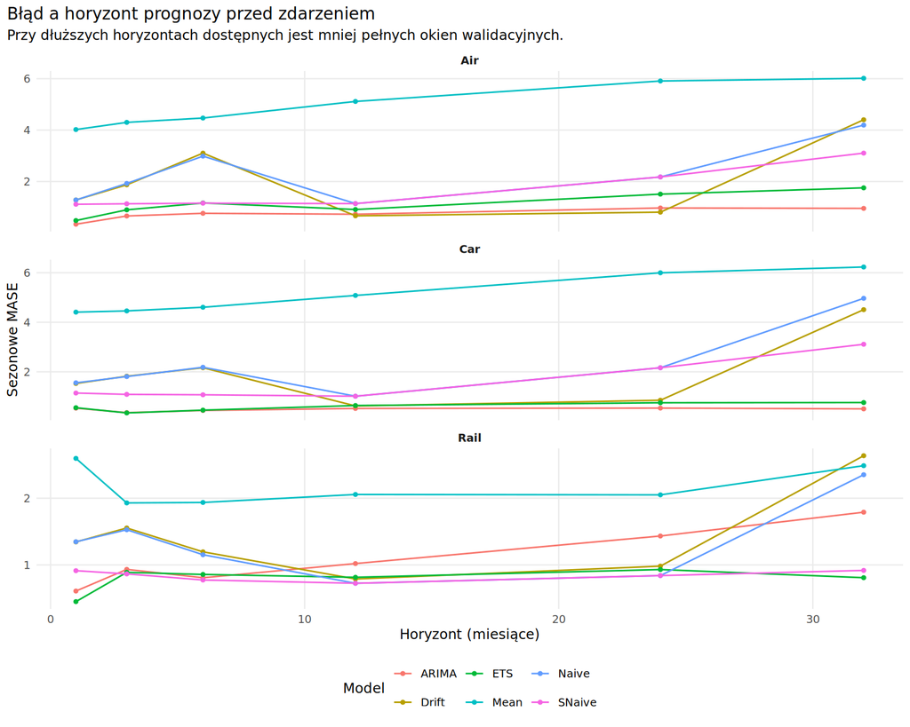

Rysunek 16: MASE w wybranych horyzontach; długie prognozy opierają się na mniejszej liczbie okien.

Tabela 9: Najlepsze modele w dodatkowej walidacji pełnych okien 32-miesięcznych.

| Szereg | Model | MASE | RMSE | MAE | MAPE (%) |
| --- | --- | --- | --- | --- | --- |
| Air | ARIMA | 0,751 | 1,996 | 1,583 | 2,981 |
| Car | ARIMA | 0,515 | 3,372 | 2,601 | 1,179 |
| Rail | ETS | 0,938 | 37,737 | 28,689 | 6,724 |

Ranking długiego horyzontu jest analizą wrażliwości i nie zmienia wcześniej ustalonego wyboru dla głównego okna 12-miesięcznego. Uśredniony wynik horyzontów 1–32 i wynik samego 32. miesiąca to różne porównania; szczegóły udostępniono w tabelach CSV.

# 6 Diagnostyka reszt

Diagnostyka dotyczy innowacji modeli dopasowanych do całej próby sprzed zdarzenia, a nie błędów prognoz po nim. Obejmuje przebieg w czasie, histogram, ACF i test Ljunga–Boxa dla opóźnienia 24. Dla ARIMA stopnie swobody pomniejszono o liczbę współczynników AR i MA, także sezonowych. Dla pozostałych metod zastosowano test bez korekty parametrów; ma on charakter diagnostyczny. Innowacje modeli z błędem multiplikatywnym mogą mieć inną skalę niż reszty w jednostkach źródłowych.

Tabela 10: Test Ljunga–Boxa dla innowacji wybranych modeli.

| Szereg | Model | N | Opóźnienie | Korekta df | Statystyka | p-value | Ocena |
| --- | --- | --- | --- | --- | --- | --- | --- |
| Air | ARIMA | 140 | 24 | 2 | 12,516 | 0.946 | Brak podstaw do odrzucenia H0 |
| Car | ARIMA | 140 | 24 | 6 | 19,222 | 0.378 | Brak podstaw do odrzucenia H0 |
| Rail | SNaive | 128 | 24 | 0 | 138,071 | <0.001 | Sygnał autokorelacji |

Mała wartość p sugeruje niewykorzystaną zależność czasową, co ogranicza zaufanie do modelu i jego przedziałów. Duża wartość p nie dowodzi, że reszty są białym szumem. Histogram służy ocenie kształtu rozkładu; idealna normalność nie jest warunkiem użyteczności prognozy punktowej.

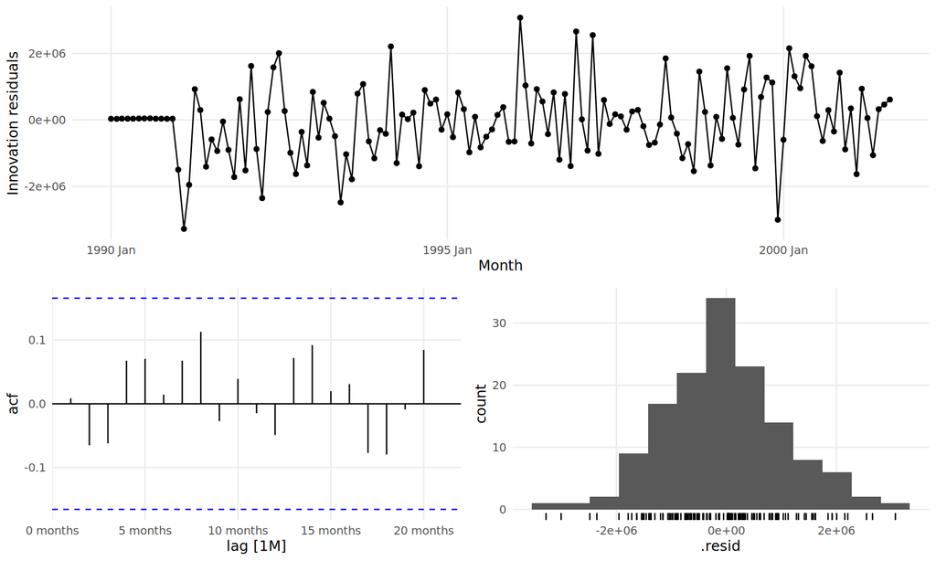

Rysunek 17: Diagnostyka graficzna reszt wybranych modeli.

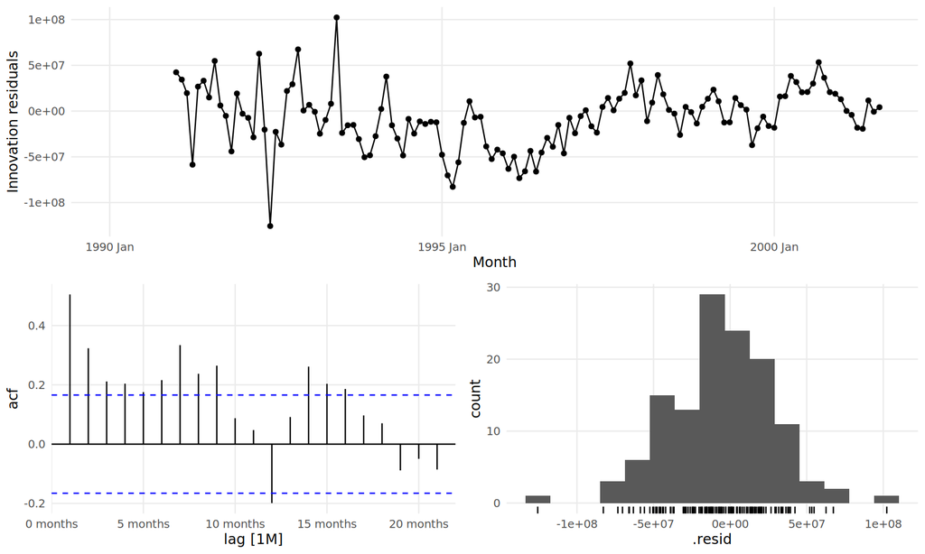

Rysunek 18: Diagnostyka graficzna reszt wybranych modeli.

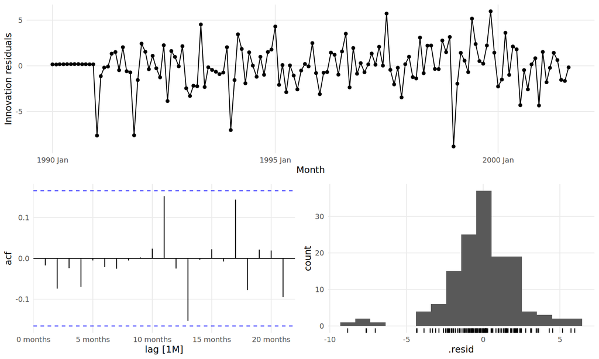

Rysunek 19: Diagnostyka graficzna reszt wybranych modeli.

# 7 Odchylenia po wrześniu 2001 r.

## 7.1 Definicje i skala zmian

Dla każdego miesiąca obliczono:

$$g_t = y_t - \widehat{y}_t,\qquad
g_t^{\%} = 100\frac{y_t-\widehat{y}_t}{\widehat{y}_t}.$$

Wartość ujemna oznacza poziom niższy od prognozy. Dla okna H miesięcy procent skumulowany wynosi:

$$G_H^{\%} = 100\frac{\sum_{t=1}^{H}(y_t-\widehat{y}_t)}{\sum_{t=1}^{H}\widehat{y}_t}.$$

Jest to odchylenie sum, a nie zwykła średnia miesięcznych procentów. Sumy liczone są oddzielnie dla każdego szeregu. Przedziały predykcji dotyczą pojedynczych miesięcy; ich granic nie dodawano jako przedziału dla sumy. Niepewność wyboru modelu i wszystkich przyszłych szoków nie jest w pełni reprezentowana przez te przedziały.

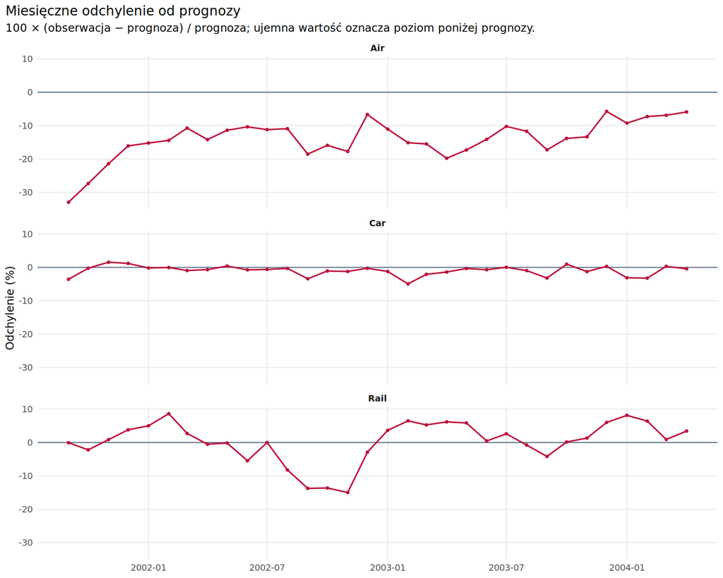

Rysunek 20: Miesięczne różnice procentowe względem prognozy.

Tabela 11: Odchylenia w ustalonych oknach od września 2001 r.

| Szereg | Model | Miesiące | Suma obserwacji | Suma prognoz | Różnica sum | Różnica (%) |
| --- | --- | --- | --- | --- | --- | --- |
| Air | ARIMA | 3 | 128,62 | 176,87 | -48,25 | -27,28 |
| Car | ARIMA | 3 | 694,05 | 699,49 | -5,44 | -0,78 |
| Rail | SNaive | 3 | 1 344,46 | 1 351,09 | -6,63 | -0,49 |
| Air | ARIMA | 6 | 268,54 | 341,99 | -73,46 | -21,48 |
| Car | ARIMA | 6 | 1 342,41 | 1 345,65 | -3,24 | -0,24 |
| Rail | SNaive | 6 | 2 620,03 | 2 558,48 | 61,55 | 2,41 |
| Air | ARIMA | 12 | 620,31 | 739,17 | -118,86 | -16,08 |
| Car | ARIMA | 12 | 2 817,94 | 2 828,28 | -10,34 | -0,37 |
| Rail | SNaive | 12 | 5 575,82 | 5 580,26 | -4,45 | -0,08 |
| Air | ARIMA | 32 | 1 722,42 | 2 000,86 | -278,44 | -13,92 |
| Car | ARIMA | 32 | 7 551,78 | 7 625,10 | -73,32 | -0,96 |
| Rail | SNaive | 32 | 14 633,92 | 14 623,42 | 10,50 | 0,07 |

Sumy i ich różnice wyrażono w jednostkach prezentacyjnych z tabeli danych: Air w mld pasażerom mil, Rail w mln pasażerom mil, Car w mld mil pojazdów.

## 7.2 Wrażliwość na metodę

Tabela 12: Pierwszy rok: jak oszacowanie procentowe zmienia się między metodami.

| Szereg | ARIMA | Drift | ETS | Mean | Naive | SNaive |
| --- | --- | --- | --- | --- | --- | --- |
| Air | -16,08 | -26,77 | -15,65 | 7,22 | -25,09 | -13,24 |
| Car | -0,37 | -8,21 | -0,07 | 14,91 | -6,70 | 1,93 |
| Rail | -0,19 | -18,10 | -0,96 | -4,90 | -17,36 | -0,08 |

Rozbieżność wyników między metodami jest częścią niepewności scenariusza. Mean ignoruje wieloletni trend, Naive utrzymuje ostatni miesiąc, a Drift pomija wzorzec sezonowy. Dlatego sama rozpiętość sześciu liczb nie stanowi przedziału ufności ani zestawu równie wiarygodnych oszacowań efektu.

# 8 Wnioski i ograniczenia

1. **Lotnictwo:** wybrany wcześniej model ARIMA daje odchylenie sumy w pierwszym roku równe **-16,08%**; dla całych 32 miesięcy jest to **-13,92%**. Wynik pokazuje skalę różnicy względem prognoz, a nie zmianę liczby pasażerów.
2. **Kolej:** analogiczne wartości to **-0,08%** i **0,07%**, dla modelu SNaive. Wniosek należy czytać wraz z diagnostyką reszt i analizą wrażliwości.
3. **Ruch drogowy:** odchylenia wynoszą **-0,37%** w pierwszym roku i **-0,96%** w pełnym okresie, według modelu ARIMA. Miara obejmuje przebieg pojazdów, więc nie stanowi bezpośredniego dowodu wzrostu lub spadku liczby podróżujących.

Prognozy reprezentują kontynuację wcześniejszych wzorców przy założeniach danego modelu. Brak grupy kontrolnej i dodatkowych zmiennych oznacza, że inne czynniki gospodarcze, zmiany podaży transportu i późniejsze zdarzenia mogą współtworzyć obserwowane różnice. Rail i Car także mogły reagować na zdarzenie, więc nie potraktowano ich jako niezakłóconych zmiennych kontrolnych dla lotnictwa. Porównanie trzech agregatów nie identyfikuje substytucji środków transportu.

Wchodzenie obserwacji do szerokiego przedziału predykcji nie oznacza automatycznie pełnego powrotu do wcześniejszej ścieżki. Dla 32 miesięcy rośnie zarówno błąd ekstrapolacji, jak i możliwość wpływu innych zdarzeń. Analiza nie jest też prognozą skutków przyszłych ataków.

# 9 Odtwarzalność i materiały

Kod, źródłowy zbiór danych, tabele CSV, wykresy, wersje pakietów i zapis środowiska znajdują się w repozytorium Benvenuteo/us-travel-9-11-analysis. Analizę uruchamia polecenie `Rscript scripts/run_analysis.R`, a raport `quarto render reports/travel_9_11.qmd`. Przed uruchomieniem należy odtworzyć zależności zgodnie z README.

```
Zarejestrowane ostrzeżenia wykonania są zapisane w pliku analysis-warnings.txt.
```

Tabela 13

| Ostrzeżenie |
| --- |
| NaNs produced |
| Removed 12 rows containing missing values or values outside the scale range (`geom_line()`). |
| Removed 12 rows containing missing values or values outside the scale range (`geom_point()`). |
| Removed 12 rows containing non-finite outside the scale range (`stat_bin()`). |
| Removed 12 rows containing missing values or values outside the scale range (`geom_rug()`). |

Komunikaty o 12 usuniętych wierszach dotyczą brakujących początkowych reszt metody SNaive: pierwsze 12 miesięcy nie ma wcześniejszej obserwacji z tego samego miesiąca roku. Nie oznaczają usunięcia danych wejściowych. Komunikat numeryczny `NaNs produced` zachowano do audytu; kod sprawdził skończoność wszystkich końcowych prognoz, przedziałów i ocenianych błędów.

Podstawa metodologiczna: Hyndman i Athanasopoulos, [*Forecasting: Principles and Practice*, rozdział 5](https://otexts.com/fpp3/toolbox.html). Dokumentacja implementacji: [fable](https://fable.tidyverts.org/), [fabletools](https://fabletools.tidyverts.org/), [feasts](https://feasts.tidyverts.org/) i ggtime. Historyczny raport BTS jest kontekstem i źródłem danych; jego wyniki nie zastępują obliczeń przeprowadzonych w tym projekcie.